# 2nd year Physical Chemistry, Xiamen University

# Supervision1: Thermodynamics

## Work set problems

### Useful data

$ \text{Gas constant}, R = 8.3145 \ J \cdot K^{−1} \cdot mol^{−1}$  
$ 1 \ \text{atmosphere} = 1.01325 \times 10^5 \ N \cdot m^{−2} (or \ Pa) = 760 \ mmHg$  
$ 1 \ Torr = 1 \ mmHg = 133.322 \ N \cdot m^{−2} ; \ 1 \ bar = 10^5 \ N \cdot m^{−2} ; \ 0 °C= 273.15 \ K$  
$ \text{Avogadro's constant}, \ N_A= 6.022 \times 10^{23} \ mol^{−1} ; \ 1 amu = 1.66056 \times 10^{−27} \ kg$  
$ \text{Boltzmann's constant}, \ k = 1.38066 \times 10^{−23} J \cdot K^{−1}$  
$ \text{Faraday constant}, \ F = 96485 \ C \cdot mol^{−1}$

```python
from math import log
# Constants
R = 8.3145 # JK^(-1)mol^(-1)
atm = 1.01325e5 # Pa
NA = 6.022e23 # mol^(-1)
```

### 1

#### (a)

$$ pV = nRT $$

#### (b)

$$ m_{\text{gas}} = 1.3447g$$

$$ n = \frac{pV}{RT} = \frac{\frac{750.0mmHg}{760mmHg} \times 1.01325 \times 10^5 Pa \times 535.0 \times 10^{-6} m^{3}}{8.314J \cdot K^{-1} \cdot mol^{-1} \times(100 + 273.15) K} = 0.01724 \ mol$$

$$ M = \frac{m}{n} = \frac{1.3447g}{0.01724mol} = 77.99 \ g \cdot mol^{-1}$$

```python
# (a)
print("(a)")
V = (1 * R * 273.15) / (1 * atm)
print("V = {} m^3".format(V))

# (b)
print("(b)")
# for gas
m = 1.3447
T = 100 + 273.15
V = 535.0e-6
p = (750/760) * atm
n = (p * V) / (R * T)
M = m / n
print("T = {} K, V = {} m^3, p = {} Pa".format(T, V, p))
print("n = {} mol, M = {} g/mol".format(n, M))
```

```
(a)
V = 0.022414070318282752 m^3
(b)
T = 373.15 K, V = 0.000535 m^3, p = 99991.77631578947 Pa
n = 0.017242430413097216 mol, M = 77.98784555213146 g/mol
```

### 2

#### (a)

$$ \delta w' = p_{ext}dV $$ why $p_{ext}$?
For reversible and isothermal process: $$ p_{ext} = p $$ $$ \delta w' = p_{ext}dV = pdV$$ $$ w' = \int_{V_i}^{V_F} pdV = \int_{V_i}^{V_F} \frac{nRT}{V} dV = nRT\ln(\frac{V_f}{V_i})$$

#### (b)

$$ pV = nRT $$

#### (c)

$$ p_{\text{gas}} \ \text{v.s.} \ p_{\text{ext}} $$

#### (d)

$$ V_f = \frac{n_fR_fT_f}{p_f} = \frac{nRT}{p_{ext}} $$ $$ w' = p_{{ext}}\Delta V $$

#### (e)

$$\Delta U = 0$$

#### (f)

$$ w' = -w = \int_{V_i}^{V_F} pdV = \int_{V_i}^{V_F} \frac{nRT}{V} dV = nRT\ln(\frac{V_f}{V_i})$$

```python
# (b)
print("(b)")
n = 4e-3
T = 298
V = 10e-6
p = (n * R * T) / V
print("p = {} Pa = {} atm".format(p, p / atm))

# (d)
print("(d)")
V_i = V
p_f = p_ext = 1 * atm
V_f = (n * R * T)/p_2
print("V_f = {} Pa".format(V_f))
w = - p_ext * (V_f - V_i)
print("w = {} J".format(w))

# (f)

print("(f)")
w_rev = - n * R * T * log(V_f / V_i)
print("w_rev = {} J".format(w_rev))
```

```
(b)
p = 991088.4 Pa = 9.781282013323464 atm
(d)
V_f = 9.781282013323466e-05 Pa
w = -8.897634000000002 J
(f)
w_rev = -22.601479192143078 J
```

### 4

#### (a)

definition of entropy: $$ dS = \delta q_{rev} / T $$ for surroundings:
$$ \delta S_{surr} = \frac{q_{surr}}{T_{surr}} = \frac{-q_{sys}}{T_{sys}} $$

#### (b)

$$\Delta S_{sys}$$

#### (c)

$$\Delta S_{univ} = \Delta S_{sys} + \Delta S_{surr}$$

```python
# (a)
print("(a)")
q_irr = -w
q_rev = -w_rev
delta_S_surr_rev = -q_rev / T
delta_S_surr_irr = -q_irr / T

print("irr: deltaS = {}, rev: deltaS = {}".format(delta_S_surr_irr, delta_S_surr_rev))

# (c)
print("(c)")
delta_S_sys_irr = -delta_S_surr_rev
delta_S_univ_irr = (delta_S_sys_irr + delta_S_surr_irr)
print("delta_S_univ_irr = {}".format(delta_S_univ_irr))
```

```
(a)
irr: deltaS = -0.029857832214765106, rev: deltaS = -0.0758438899065204
(c)
delta_S_univ_irr = 0.04598605769175529
```

### 6

#### (a)

$$\Delta U = q + w = q - p\Delta V$$ $$nC_V = \frac{\delta q_V}{dT} = \left( \frac{dU}{dT} \right) _V$$

#### (b)

$$C_p \ v.s. \ C_V$$ for gas?
for ideal gas?

### 8

#### (a)

$$dS = \delta q_{rev}/T$$ $$dU = \delta q - pdV = TdS - pdV$$ Notice all of them are state functions, so 'reversible' doesn't matter.

$$H = U + pV$$ $$dH = TdS + Vdp$$ for constant presure $$dS_m^0 = dH/T = C_{p} dT/T$$ $$S_m^0(T2) - S_m^0(T1) = C_{p} \ln \frac{T_2}{T_1}$$

#### (c)

$$C_p(T) = \alpha + \beta T$$

```python
# (b)
print("(b)")
T1 = 298
T2 = 398
S_T1 = 191.6
C_p = 29.7

S_T2 = S_T1 + C_p * log(T2 / T1)
print("S_T2 = {} JK^-1mol^-1".format(S_T2))

# (d)
print("(d)")
alpha = 28.58
beta = 3.77e-3
S_T2 = S_T1 + alpha * log(T2 / T1) + beta * (T2 - T1)
print("S_T2 = {} JK^-1mol^-1".format(S_T2))
```

```
(b)
S_T2 = 200.19394800773728 JK^-1mol^-1
(d)
S_T2 = 200.24686646670477 JK^-1mol^-1
```

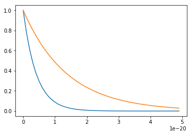

```python
# Boltzman distribution
# n_i = n_0*exp(-epsilon_i/(kT))
%matplotlib inline

import matplotlib.pyplot as plt
import numpy as np

k = 1.38e-23 # J/K
T = 298 # K
epsilon_i = np.arange(0, 5e-20, 1e-21)
n = np.exp(-epsilon_i / (k * T))
plt.plot(epsilon_i, n)

T2 = 1000
n_t2 = np.exp(-epsilon_i / (k * T2))
plt.plot(epsilon_i, n_t2)
```

## Questions

Here in the part, questions are summarized from the supervision. Questions are mostly proposed by students themselves and I select those where students did not reach an answer through their discussions.  
This part is of great importance for it reveals students understanding of the course, it may guide the future improvement of the lecture.  
Thanks Haowen Zhang, Shuming Xing, Shimian Li and Zhilin Song for their questions and discussions.

1. $C_V$  
   As $C_V$ can be given by $C_V = \left(\frac{\partial U}{\partial T}\right)_V$, where both U and T are state functions. So is $C_V$ also a state function?  
   If so, $C_V$'s value does not depend on the process, can $C_V$ be written as $\frac{dU}{dT}$ ?  
   *# Partial_derivative # State_function*
2. Pressure p & Work W  
   In both the case of ideal gas expansion and compression, the work is done are calculated by $p_\text{ext}dV$, why?  
   For an irreversible process, where $p_\text{gas} \neq p_\text{ext}$. So what is the $(p_\text{gas} - p_\text{ext})dV$ and where does this part go?  
   How to understand the behaviour of piston during the expansion process?  
   *# Ideal_gas_expansion # Work*